# Statistical inference

IQA lecture 3

Charles Lanfear

2026-10-28

## Today

- Code
  - `ggplot2`
  - More tables
  - `{broom}` for model output
- Stats
  - Chi-square test
  - Simple OLS regression

# Some review

## London crime

Let’s load another example dataset:

Real Metropolitan Police recorded crime in the 32 London boroughs (no City of London) in 2021

```r
library(tidyverse)
metro_2021 <-
  read_csv("https://clanfear.github.io/ioc_iqa/_data/metro_2021.csv")
```

I obtained these from `data.police.uk`—it is easy to get your own for nearly anywhere in the UK, and in any recent period.

I also linked them to data on deprivation and subregions, which would take more work!<sup>1</sup>

[^1]: We’ll actually make these in CRMW next term!

## London crime

```r
glimpse(metro_2021)
```

```
Rows: 384
Columns: 10
$ borough                      <chr> "Barking and Dagenham", "Bark…
$ month                        <date> 2021-01-01, 2021-02-01, 2021…
$ antisocial_behaviour         <dbl> 688, 585, 600, 531, 469, 507,…
$ burglary                     <dbl> 87, 105, 81, 85, 106, 90, 75,…
$ robbery                      <dbl> 30, 50, 49, 40, 47, 46, 42, 3…
$ violence_and_sexual_offences <dbl> 469, 449, 561, 564, 589, 617,…
$ subregion                    <chr> "East", "East", "East", "East…
$ deprivation                  <chr> "High", "High", "High", "High…
$ pop                          <dbl> 221495, 221495, 221495, 22149…
$ area                         <dbl> 36.1, 36.1, 36.1, 36.1, 36.1,…
```

## `distinct()`

These data have monthly observations for each borough.

If we wanted to look at only unique observations of boroughs, we can use `distinct()`

```r
metro_2021 |>
  distinct(borough) |>
  head()
```

```
# A tibble: 6 × 1
  borough
  <chr>
1 Barking and Dagenham
2 Barnet
3 Bexley
4 Brent
5 Bromley
6 Camden
```

## `summarize()`

Just as a quick check, let’s see how many boroughs and months are in the data

```r
metro_2021 |>
  summarize(n_boroughs  = n_distinct(borough),
            n_months    = n_distinct(month),
            sample_size = n())
```

```
# A tibble: 1 × 3
  n_boroughs n_months sample_size
       <int>    <int>       <int>
1         32       12         384
```

Looks like every borough is seen in 12 months

```r
32 * 12
```

```
[1] 384
```

## Another check

A different way to see if all boroughs are observed 12 times is to count observations of each borough…

```r
metro_2021 |> count(borough) |> head(3)
```

```
# A tibble: 3 × 2
  borough                  n
  <chr>                <int>
1 Barking and Dagenham    12
2 Barnet                  12
3 Bexley                  12
```

… then count how many of each value of `n`

```r
metro_2021 |> count(borough) |> count(n) # This makes a warning!
```

```
# A tibble: 1 × 2
      n    nn
  <int> <int>
1    12    32
```

Every value of `n` was 12, so there were 32 values of 12.

## Saving a subset

If we think a particular subset will be used repeatedly, we can save it and give it a name like any other object:

```r
westminster <- metro_2021 |> filter(borough == "Westminster")
head(westminster, 4)
```

```
# A tibble: 4 × 10
  borough     month      antisocial_behaviour burglary robbery
  <chr>       <date>                    <dbl>    <dbl>   <dbl>
1 Westminster 2021-01-01                 1501      150      64
2 Westminster 2021-02-01                 1326      150      51
3 Westminster 2021-03-01                 1474      189      76
4 Westminster 2021-04-01                 1396      155     126
# ℹ 5 more variables: violence_and_sexual_offences <dbl>,
#   subregion <chr>, deprivation <chr>, pop <dbl>, area <dbl>
```

*And now for something completely different*

# Plotting

[figure not shown]

## Base R plots from 2 weeks ago

```r
plot(robbery ~ month,
     data = westminster,
     xlab = "Month",
     ylab = "Robbery",
     main =
       "Robbery in Westminster",
     col = "red",
     cex.lab = 1.5,
     cex.main= 1.5,
     pch = 16)
```

[figure not shown]

## `ggplot2`

An alternative way of plotting many prefer (myself included) uses the `ggplot2` package in R, which is part of the `tidyverse`.

```r
library(ggplot2)
```

The core idea underlying this package is the [**layered grammar of graphics**](https://doi.org/10.1198/jcgs.2009.07098): we can break up elements of a plot into pieces and combine them like nouns, verbs, and adjectives into sentences.

## Robberies in `ggplot`

```r
ggplot(data = westminster,
        aes(x = month,
            y = robbery)) +
  geom_point()
```

[figure not shown]

*Weird syntax and an ugly plot—what’s going on here?*

## Structure of a ggplot

`ggplot2` graphics objects consist of two primary components:

**Layers**, the components of a graph.

- We *add* layers to a `ggplot2` object using `+`.
- This includes lines, shapes, and text.

**Aesthetics**, which determine how the layers appear.

- We *set* aesthetics using *arguments* (e.g. `color="red"`) inside layer functions.
- This includes locations, colors, and sizes.
- Aesthetics also determine how data *map* to appearances.

## Layers

**Layers** are the components of the graph, such as:

- `ggplot()`: The initial plot canvas
- `geom_point()`: Scatterplot points
- `geom_line()`: Lines between data points
- `labs()`: Plot title and axis labels
- `facet_wrap()`: Divides plot into a sequence of panels
- `facet_grid()`: Divides plot into a grid of plot panels
- `theme_bw()`: Replace default gray background with black-and-white

Layers are separated by a `+` sign.

## Aesthetics

**Aesthetics** control the appearance of the layers:

- `x`, `y`: $x$ and $y$ coordinate values to use
- `color`: Color of elements based on some data value
- `group`: Describe which data points are grouped together (often used with lines)
- `size`: Size of points/lines based on some data value
- `alpha`: Transparency based on some data value

## Aesthetics: Setting vs. mapping

Layers take arguments to control their appearance, such as point/line colors or transparency (`alpha` between 0 and 1).

- Arguments like `color`, `size`, and `fill` can be used directly on layers (**setting aesthetics**), e.g. `geom_point(color = "red")`. These *don’t depend on the data*.
- Arguments inside `aes()` (**mapping aesthetics**) will *depend on the data*, e.g. `geom_point(aes(color = continent))`.
- `aes()` in the `ggplot()` layer applies aesthetics to all layers, but can be changed on individual layers

This may seem pedantic, but precise language makes searching for help easier.

Now let’s see all this jargon in action.

## Westminster robbery

1: Base plot

```r
ggplot(data  = westminster,
       aes(x = month,
           y = robbery))
```

[figure not shown]

Initialize the plot with `ggplot()` and `x` and `y` aesthetics **mapped** to variables.

## Westminster robbery

2: Scatterplot

```r
ggplot(data  = westminster,
       aes(x = month,
           y = robbery)) +
  geom_point()
```

[figure not shown]

Add a scatterplot **layer**

## Westminster robbery

3: Point color and size

```r
ggplot(data  = westminster,
       aes(x = month,
           y = robbery)) +
  geom_point(color = "red",
             size  = 3)
```

[figure not shown]

**Set** aesthetics to make the points large and red

## Westminster robbery

4: X-axis label

```r
ggplot(data  = westminster,
       aes(x = month,
           y = robbery)) +
  geom_point(color = "red",
             size  = 3) +
  labs(x = "Month")
```

[figure not shown]

Add a label layer to capitalize the x-axis label

## Westminster robbery

5: Y-axis label

```r
ggplot(data  = westminster,
       aes(x = month,
           y = robbery)) +
  geom_point(color = "red",
             size  = 3) +
  labs(x = "Month",
       y = "Robbery")
```

[figure not shown]

Add text to clean up the y-axis label

## Westminster robbery

6: Title

```r
ggplot(data  = westminster,
       aes(x = month,
           y = robbery)) +
  geom_point(color = "red",
             size  = 3) +
  labs(x = "Month",
       y = "Robbery",
       title =
        "Robbery in Westminster")
```

[figure not shown]

Add a title

## Westminster robbery

7: Theme

```r
ggplot(data  = westminster,
       aes(x = month,
           y = robbery)) +
  geom_point(color = "red",
             size  = 3) +
  labs(x = "Month",
       y = "Robbery",
       title =
        "Robbery in Westminster") +
  theme_bw()
```

[figure not shown]

Pick a basic theme with a new layer

## Westminster robbery

8: Text size

```r
ggplot(data  = westminster,
       aes(x = month,
           y = robbery)) +
  geom_point(color = "red",
             size  = 3) +
  labs(x = "Month",
       y = "Robbery",
       title =
        "Robbery in Westminster") +
  theme_bw(base_size = 18)
```

[figure not shown]

Increase the base text size

## Plotting all boroughs

We have a plot we like for Westminster…

… but what if we want *all the boroughs*?

## Plotting all boroughs

1: A mess!

```r
 ggplot(data  = metro_2021,
        aes(x = month,
            y = robbery)) +
  geom_point(color = "red",
             size = 3) +
  labs(x     = "Month",
       y     = "Robbery",
       title =
         "Robbery in London") +
  theme_bw(base_size = 18)
```

[figure not shown]

We can’t tell boroughs apart! Maybe we could follow *lines*?

## Plotting all boroughs

2: Lines

```r
 ggplot(data  = metro_2021,
        aes(x = month,
            y = robbery)) +
  geom_line(color = "red",
            linewidth  = 3) +
  labs(x     = "Month",
       y     = "Robbery",
       title =
         "Robbery in London") +
  theme_bw(base_size = 18)
```

[figure not shown]

`ggplot2` doesn’t know how to connect the lines!

## Plotting all boroughs

3: Grouping

```r
 ggplot(data  = metro_2021,
        aes(x = month,
            y = robbery,
            group = borough)) +
  geom_line(color = "red",
            linewidth  = 3) +
  labs(x     = "Month",
       y     = "Robbery",
       title =
         "Robbery in London")+
  theme_bw(base_size = 18)
```

[figure not shown]

That looks more reasonable… but the lines are too thick!

## Plotting all boroughs

4: Size

```r
 ggplot(data  = metro_2021,
        aes(x = month,
            y = robbery,
            group = borough)) +
  geom_line(color = "red") +
  labs(x     = "Month",
       y     = "Robbery",
       title =
         "Robbery in London") +
  theme_bw(base_size = 18)
```

[figure not shown]

Much better… but maybe we can do highlight subregions?

## Plotting all boroughs

5: Color

```r
 ggplot(data  = metro_2021,
        aes(x = month,
            y = robbery,
            group = borough,
            color = subregion)) +
  geom_line() +
  labs(x     = "Month",
       y     = "Robbery",
       title =
         "Robbery in London") +
  theme_bw(base_size = 18)
```

[figure not shown]

Hmmm, hard to make out… why not separate subregions completely?

## Plotting all boroughs

6: Facets

```r
 ggplot(data  = metro_2021,
        aes(x = month,
            y = robbery,
            group = borough,
            color = subregion)) +
  geom_line() +
  facet_wrap(~subregion) +
  labs(x     = "Month",
       y     = "Robbery",
       title =
         "Robbery in London")+
  theme_bw(base_size = 18)
```

[figure not shown]

Looking good, but the legend is redundant!

## Plotting all boroughs

7: Legend

```r
 ggplot(data  = metro_2021,
        aes(x = month,
            y = robbery,
            group = borough,
            color = subregion)) +
  geom_line() +
  facet_wrap(~subregion) +
  labs(x     = "Month",
       y     = "Robbery",
       title =
         "Robbery in London") +
  theme_bw(base_size = 18) +
  theme(legend.position = "none")
```

[figure not shown]

The x-axis labels are overlapping!

## Plotting all boroughs

8: Axis labels

```r
 ggplot(data  = metro_2021,
        aes(x = month,
            y = robbery,
            group = borough,
            color = subregion)) +
  geom_line() +
  scale_x_date(date_labels = "%b") +
  facet_wrap(~subregion) +
  labs(x     = "Month",
       y     = "Robbery",
       title =
         "Robbery in London") +
  theme_bw(base_size = 18) +
  theme(legend.position = "none")
```

[figure not shown]

See`?strptime` to find the `%` codes for date formatting

Not bad!

## Enough for now

Don’t worry about understanding it all now—it is complicated!

… but it is worth learning because it can produce publication ready plots

We’ll return to `ggplot2` at least for a bit in every future lecture

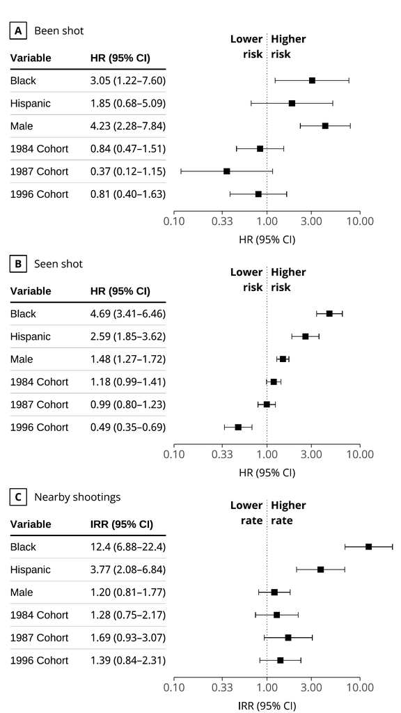

Source: [Lanfear et al. (2023) “Inequalities in Exposure to Firearm Violence by Race, Sex, and Birth Cohort From Childhood to Age 40 Years, 1995-2021”](https://jamanetwork.com/journals/jamanetworkopen/fullarticle/2804655)

## Bonus map

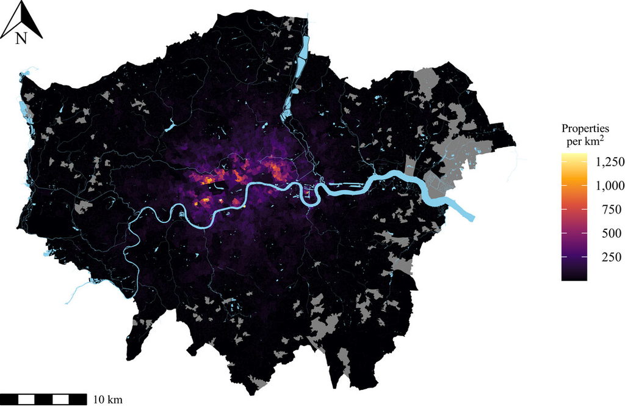

Source: [Lanfear & Kirk (2024) “The Promise and Perils of the Sharing Economy: The Impact of Airbnb Lettings on Crime”](https://doi.org/10.1111/1745-9125.12383)

## Book recommendation

[figure not shown]

- Targeted at social scientists without technical backgrounds
- Teaches good visualization principles
- Uses R, `ggplot2`, and `tidyverse`
- Free online version:
  - https://socviz.co/
- Affordable in print

# Statistical inference

[figure not shown]

## `communities` data

Let’s return to the `communities` data we’ve used before—making sure to fix the ordinal variables again

```r
communities <-
  read_csv("https://clanfear.github.io/ioc_iqa/_data/communities.csv") |>
  mutate(disadvantage =
           factor(disadvantage, levels = c("Low", "Medium", "High")),
         incarceration =
           factor(incarceration, levels = c("Low", "Medium", "High")))
glimpse(communities)
```

```
Rows: 300
Columns: 5
$ area          <chr> "Urban", "Urban", "Rural", "Rural", "Urban",…
$ pop_density   <dbl> 18.166008, 21.356727, 10.023975, 14.926138, …
$ crime_rate    <dbl> 28.63123, 58.60800, 14.19840, 22.29075, 79.7…
$ disadvantage  <fct> Low, Medium, Low, Medium, High, High, Low, L…
$ incarceration <fct> High, Medium, High, Medium, High, High, High…
```

## Cross-tab

Say we tabulate our data and see this association in our sample:

```r
library(janitor) # For the tabyl function
communities |> tabyl(disadvantage, area) |> adorn_title()
```

```
               area
 disadvantage Rural Urban
          Low    63    39
       Medium    49    48
         High    41    60
```

It looks like disadvantage has different patterns in rural and urban areas

We want to know if there’s a real relationship in the population

How do we figure this out?

## Chi-square test

`janitor` adds a `chisq.test()` function that works on its special tables

```r
communities |> tabyl(disadvantage, area) |> chisq.test()
```

```
    Pearson's Chi-squared test

data:  tabyl(communities, disadvantage, area)
X-squared = 9.1153, df = 2, p-value = 0.01049
```

This is the same result we saw in CRM yesterday: There appears to be an association.

If you’re curious how p-values are calculated, they come from cumulative probability distributions—which R has built in!

```r
1 - pchisq(9.1153, df = 2)
```

```
[1] 0.01048667
```

## How unlikely is that?

```r
tibble(x = seq(0, 15, 0.1),
       density = dchisq(x, df = 2)) |>
  ggplot(aes(x = x, y = density)) +
  geom_line() +
  coord_cartesian(expand = FALSE) +
  geom_vline(xintercept = 9.1153,
             color = "red")
```

[figure not shown]

That is really unlikely to occur by chance:

## A prettier table

There are many ways to make nicer looking tables in R

For very simple tables using dataframes, I use `kable()` in `{knitr}`

```r
communities |>
  tabyl(disadvantage, area) |>
  adorn_title() |>
  knitr::kable() # Access a package function without loading it
```

|  | area |  |
| --- | --- | --- |
| disadvantage | Rural | Urban |
| Low | 63 | 39 |
| Medium | 49 | 48 |
| High | 41 | 60 |

## More complex

If you want to make a publication ready table that will work in any output format, such as PDF, Word, or HTML, [your best bet is `{flextable}`](https://ardata-fr.github.io/flextable-book/)

```r
library(flextable)
communities |>
  rename(Disadvantage = disadvantage) |>
  tabyl(Disadvantage, area) |>
  flextable() |>
  add_header_lines("Table 1. Disadvantage by area")
```

| Table 1. Disadvantage by area Disadvantage | Table 1. Disadvantage by area Rural | Table 1. Disadvantage by area Urban |
| --- | --- | --- |
| Low | 63 | 39 |
| Medium | 49 | 48 |
| High | 41 | 60 |

It can be complicated, but it can do just about anything…

## `{flextable}` is… flexible

[figure not shown]

Source: [Flextable Gallery](https://www.ardata.fr/en/flextable-gallery/2021-01-12-mario-kart/)

## I suppose you can use it for articles too

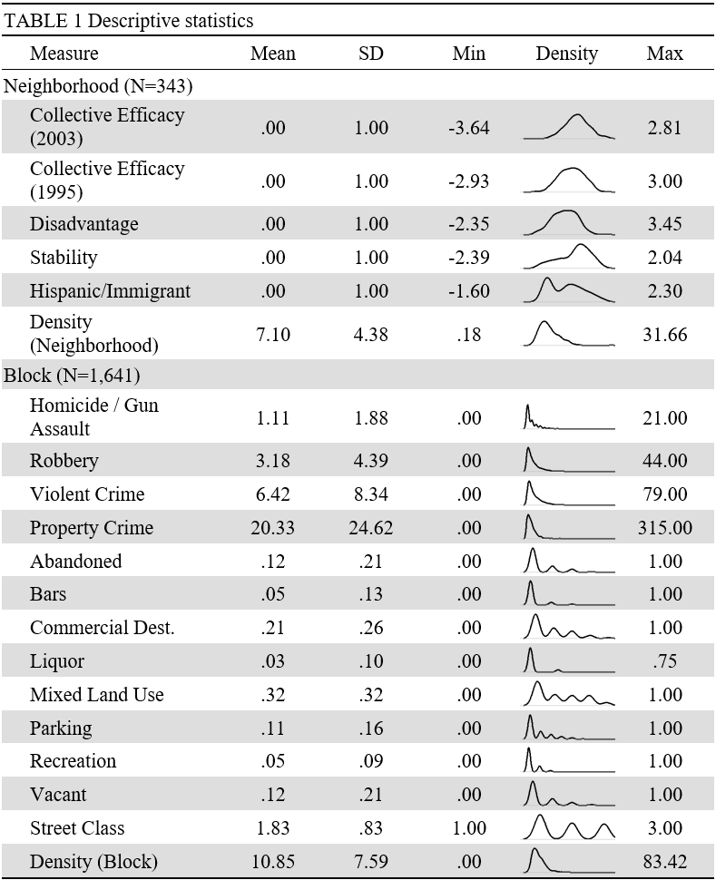

Source: [Lanfear (2022) “Collective efficacy and the built environment”](https://doi.org/10.1111/1745-9125.12304)

## Bar plots

Aside from tables, you may want to plot categorical data

```r
ggplot(communities,
       aes(x = disadvantage)) +
  geom_bar()
```

`geom_bar()` tabulates counts of values of categorical variables and makes a bar plot

[figure not shown]

## Column plots

If you’ve already tabulated the data, you can use `geom_col()`:

```r
communities |>
  count(disadvantage) |>
  ggplot(aes(y = n,
             x = disadvantage)) +
  geom_col()
```

`geom_col()` creates a bar as tall as $y$

[figure not shown]

All `geom_bar()` does differently is run `count()` for you!

## Filled bar plots

Adding a `fill` aesthetic will color the bars by a second variable

```r
ggplot(communities,
       aes(x    = disadvantage,
           fill = area)) +
  geom_bar()
```

[figure not shown]

## Dodgy bar plots

Adding `position = "dodge"` in `geom_bar()` will unstack them

```r
ggplot(communities,
       aes(x    = disadvantage,
           fill = area)) +
  geom_bar(position = "dodge")
```

[figure not shown]

# Linear regression

[video not shown]

Credit: [Edmund Helmur](https://twitter.com/theotheredmund/status/1349453230762196992?s=20&t=bBDscDYt2was9ABePCcZhQ)

## `lm()`

We can run an OLS linear model in R using `lm()`

It takes a **formula** as the first argument, e.g. `y ~ x`

```r
cr_pd_lm <- lm(crime_rate ~ pop_density, data = communities)
cr_pd_lm
```

```
Call:
lm(formula = crime_rate ~ pop_density, data = communities)

Coefficients:
(Intercept)  pop_density
    -20.777        3.094
```

By default, it won’t produce much output—you probably wanted significance tests!

## `summary()`

To get detailed output, use `summary()` on the output from `lm()`

```r
summary(cr_pd_lm)
```

```
Call:
lm(formula = crime_rate ~ pop_density, data = communities)

Residuals:
    Min      1Q  Median      3Q     Max
-35.171  -7.423  -0.983   5.584  55.867

Coefficients:
            Estimate Std. Error t value Pr(>|t|)
(Intercept) -20.7769     2.0909  -9.937   <2e-16 ***
pop_density   3.0939     0.1314  23.544   <2e-16 ***
---
Signif. codes:  0 '***' 0.001 '**' 0.01 '*' 0.05 '.' 0.1 ' ' 1

Residual standard error: 12.9 on 298 degrees of freedom
Multiple R-squared:  0.6504,    Adjusted R-squared:  0.6492
F-statistic: 554.3 on 1 and 298 DF,  p-value: < 2.2e-16
```

## `lm()` output is a list

`lm()` produces a lot more information than what is shown by `summary()` however. We can see the structure of `lm()` output using `str()`:

```r
str(cr_pd_lm, list.len=6) # Truncating the output a bit
```

```
List of 12
 $ coefficients : Named num [1:2] -20.78 3.09
  ..- attr(*, "names")= chr [1:2] "(Intercept)" "pop_density"
 $ residuals    : Named num [1:300] -6.8 13.31 3.96 -3.11 32.83 ...
  ..- attr(*, "names")= chr [1:300] "1" "2" "3" "4" ...
 $ effects      : Named num [1:300] -436.83 -303.74 4.99 -2.73 32.31 ...
  ..- attr(*, "names")= chr [1:300] "(Intercept)" "pop_density" "" "" ...
 $ rank         : int 2
 $ fitted.values: Named num [1:300] 35.4 45.3 10.2 25.4 46.9 ...
  ..- attr(*, "names")= chr [1:300] "1" "2" "3" "4" ...
 $ assign       : int [1:2] 0 1
  [list output truncated]
 - attr(*, "class")= chr "lm"
```

`lm()` actually has an enormous quantity of output! This is a type of object called a list.

## Digging into a list

We can access parts of `lm()` output using `$` like with dataframe names:

```r
cr_pd_lm$coefficients
```

```
(Intercept) pop_density
 -20.776945    3.093886
```

We can also do this with `summary()`, which provides additional statistics:

```r
summary(cr_pd_lm)$coefficients
```

```
              Estimate Std. Error   t value     Pr(>|t|)
(Intercept) -20.776945  2.0908640 -9.937014 2.769101e-20
pop_density   3.093886  0.1314093 23.543883 5.701147e-70
```

## `broom::tidy()`

A quick way to get model output into an easy-to-use format is with the `{broom}` package’s `tidy()` function

```r
library(broom)
tidy(cr_pd_lm)
```

```
# A tibble: 2 × 5
  term        estimate std.error statistic  p.value
  <chr>          <dbl>     <dbl>     <dbl>    <dbl>
1 (Intercept)   -20.8      2.09      -9.94 2.77e-20
2 pop_density     3.09     0.131     23.5  5.70e-70
```

`tidy()` turns model output into a dataframe—so you can use `dplyr`!

```r
tidy(cr_pd_lm) |> filter(term == "pop_density")
```

```
# A tibble: 1 × 5
  term        estimate std.error statistic  p.value
  <chr>          <dbl>     <dbl>     <dbl>    <dbl>
1 pop_density     3.09     0.131      23.5 5.70e-70
```

## `broom::augment()`

`{broom}` can also add regression results back to your original data using `augment()`

This includes **predicted values** (`.fitted`) and **residuals** (`.resid`):

```r
cr_pd_lm |> augment() |> glimpse()
```

```
Rows: 300
Columns: 8
$ crime_rate  <dbl> 28.63123, 58.60800, 14.19840, 22.29075, 79.772…
$ pop_density <dbl> 18.166008, 21.356727, 10.023975, 14.926138, 21…
$ .fitted     <dbl> 35.426612, 45.298331, 10.236091, 25.402822, 46…
$ .resid      <dbl> -6.7953821, 13.3096695, 3.9623093, -3.1120717,…
$ .hat        <dbl> 0.004462361, 0.007702732, 0.005767089, 0.00333…
$ .sigma      <dbl> 12.91673, 12.89950, 12.92072, 12.92151, 12.780…
$ .cooksd     <dbl> 6.245907e-04, 4.163074e-03, 2.751664e-04, 9.76…
$ .std.resid  <dbl> -0.52790919, 1.03566799, 0.30801969, -0.241628…
```

We’ll use this later to do model diagnostics!

## Plotting regression lines

`geom_smooth()` is used to add conditional mean lines to plots—the regression line is just one type of these!

```r
communities |>
  ggplot(aes(x = pop_density,
             y = crime_rate)) +
  geom_point(alpha = 0.5) +
  labs(x = "Population Density",
       y = "Crime Rate") +
  geom_smooth(method  = "lm",
              formula = "y ~ x") +
  theme_minimal(base_size = 16)
```

[figure not shown]

By default it includes a confidence interval along the line

This is the CI for the mean *at each level of `x`*

## More lines

If you group your data, you can draw a regression line for each separately—equivalent to running a separate model on each group

```r
communities |>
  ggplot(aes(x = pop_density,
             y = crime_rate,
             group = area,
             color = area)) +
  geom_point(alpha = 0.5) +
  labs(x = "Population Density",
       y = "Crime Rate",
       color = "Area") +
  geom_smooth(method  = "lm",
              formula = "y ~ x") +
  theme_minimal(base_size = 16)
```

[figure not shown]

## Wrap-up

- That was a lot this week!
  - Take the week off on this course—focus on CRM and your other courses
- Next week will have an assignment handed out
- Most of the rest of the course is figuring out how to apply all this
  - Plus learning some more programming tools!